# Assignment 08

## Homework 8

#### Due Tuesday, November 16, 11:59 PM CT

Problems 1-3 are based on the random variable $X \sim \text{Binomial}(60, 0.4)$.

### Problem 1

### A

Calculate and report the mean and standard deviation of the distribution.

```r
n = 60
p = 0.4
mean = n * p
stdev = sqrt(n * p * (1-p))
mean
```

```
## [1] 24
```

```r
stdev
```

```
## [1] 3.794733
```

-The mean of a binomial distribution of n = 60 and p = 0.4 is 24. The standard deviation would be about 3.795.

### B

Calculate and report $\mathsf{P}(X = 25)$

```r
dbinom(25, 60, 0.4)
```

```
## [1] 0.1004824
```

The probability of exactly 25 successes in a binomial distribution (60, 0.4) is around 10 percent.

### C

Calculate and report $\mathsf{P}(X >= 25)$

```r
1 - pbinom(25, 60, 0.4)
```

```
## [1] 0.343742
```

### D

Create a graph which displays the binomial distribution with bars for $x \ge 25$ colored in a different color from the rest to help visualize your answer to **C**.

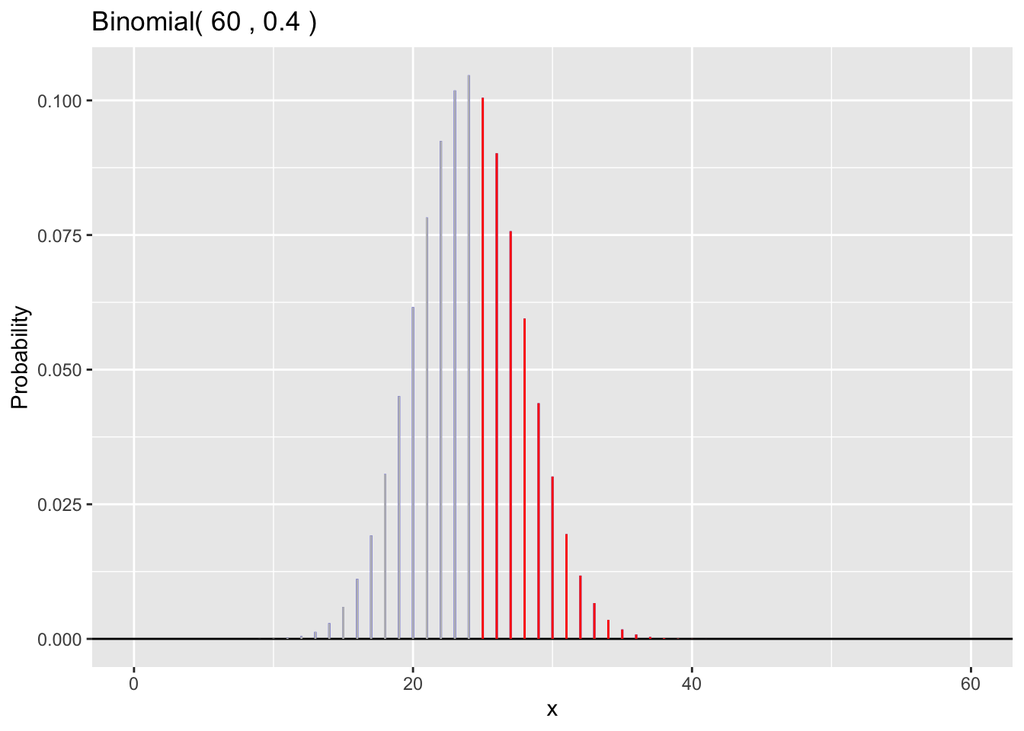

```r
gbinom(60, 0.4, scale=TRUE) +
  geom_binom_density(60, 0.4, a = NULL, b = NULL, color = "gray") +
  geom_binom_density(60, 0.4, a = 25, b = NULL, color = "red")
```

### Problem 2

What is the probability that $X$ is within one, two, and three standard deviations of the mean? Round each probability to four decimal places.

```r
round(pbinom(mean + (c(1,2,3) * stdev), 60, 0.4) - pbinom(mean - (c(1,2,3) * stdev), 60, 0.4), 4)
```

```
## [1] 0.6436 0.9529 0.9978
```

### Problem 3

Draw a graph of this binomial distribution with vertical lines with different line types at the end points of the intervals 1, 2, and 3 sigma from the mean.

- solid for $\mu \pm \sigma$
- dashed for $\mu \pm 2\sigma$
- dotted for $\mu \pm 3\sigma$

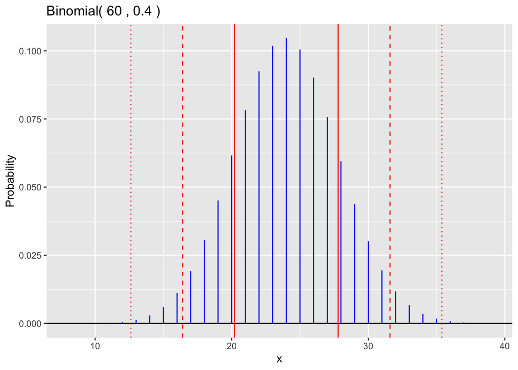

```r
gbinom(60, 0.4, scale=TRUE) +
  geom_vline(xintercept = mean + c(-1,1)*stdev,
             color = "red") +
  geom_vline(xintercept = mean + c(-2,2)*stdev,
             color = "red", linetype = "dashed") +
  geom_vline(xintercept = mean + c(-3,3)*stdev,
             color = "red", linetype = "dotted")
```

### Problem 4

### A

Create a tibble where each row corresponds to a binomial distribution with the following columns:

- `n` for $n = 1000,1001, \ldots, 10,000$
- `p` equal to 0.9 for each row
- `mu` equal to the mean
- `sigma` equal to the standard deviation
- `q.975` equal to the 0.975 quantile of the distribution
- `z = (q.975 - mu)/sigma`, the standardized z-score of the quantile
- `prob` equal to $\mathsf{P}(X \ge q.975)$, a right-tail probability for the distribution in each row

Display all columns and the rows of this table for which $n$ is a multiple of 1000.

```r
prob4 = tibble(
  n = seq(1000, 10000),
  p = 0.9,
  mu = n * p,
  sigma = sqrt(n * p * (1-p)),
  `q.975` = qbinom(0.975, n, p),
  z = (`q.975` - mu) / sigma,
  prob = 1 - pbinom(`q.975`, n, p)
)
prob4 %>%
  filter(n %% 1000 == 0)
```

```
## # A tibble: 10 × 7
##        n     p    mu sigma q.975     z   prob
##    <int> <dbl> <dbl> <dbl> <dbl> <dbl>  <dbl>
##  1  1000   0.9   900  9.49   918  1.90 0.0231
##  2  2000   0.9  1800 13.4   1826  1.94 0.0224
##  3  3000   0.9  2700 16.4   2732  1.95 0.0226
##  4  4000   0.9  3600 19.0   3637  1.95 0.0229
##  5  5000   0.9  4500 21.2   4541  1.93 0.0241
##  6  6000   0.9  5400 23.2   5445  1.94 0.0241
##  7  7000   0.9  6300 25.1   6349  1.95 0.0234
##  8  8000   0.9  7200 26.8   7252  1.94 0.0244
##  9  9000   0.9  8100 28.5   8155  1.93 0.0248
## 10 10000   0.9  9000 30     9058  1.93 0.0248
```

### B

Use a line plot to show the relationship between $n$ on the x axis and $z$ on the y axis. Add a smooth curve to highlight the trend. Describe the pattern you see.

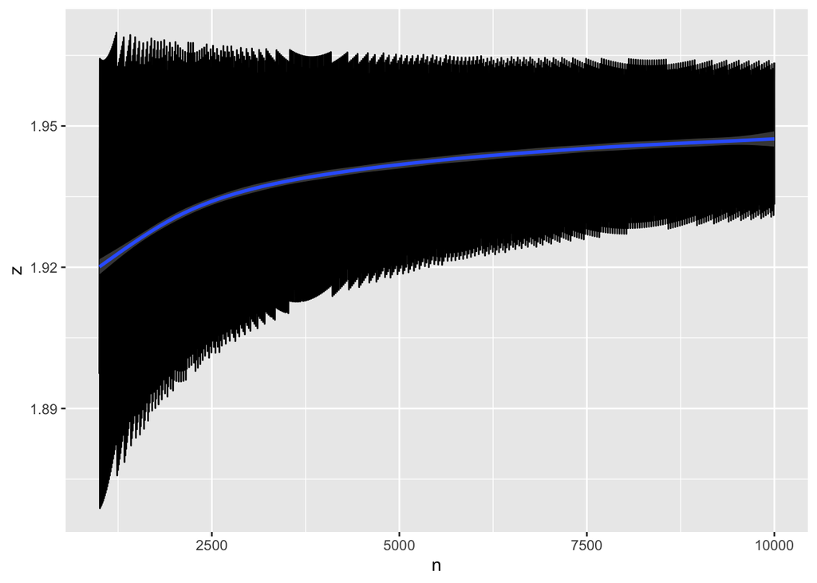

```r
prob4 %>%
  ggplot(aes(x=n, y=z)) +
  geom_line() +
  geom_smooth()
```

Of binomial distributions with the same probability, it appears that the z-scores of the 97.5th percentile gradually increase as n increases, although the rate at which the z-scores increase is continually decreasing. Meaning, up to a point (around 5000 in this case) the distribution of z-scores follow a radical trend whereas past that point it is fairly linear and constant.

### C

What is the average of the values of $z$ for $n > 9000$?

```r
prob4 %>%
  filter(n > 9000) %>%
  summarize(mean(z))
```

```
## # A tibble: 1 × 1
##   `mean(z)`
##       <dbl>
## 1      1.95
```

### D

Plot the right tail probability `prob` on y axis versus `n` on the x axis.

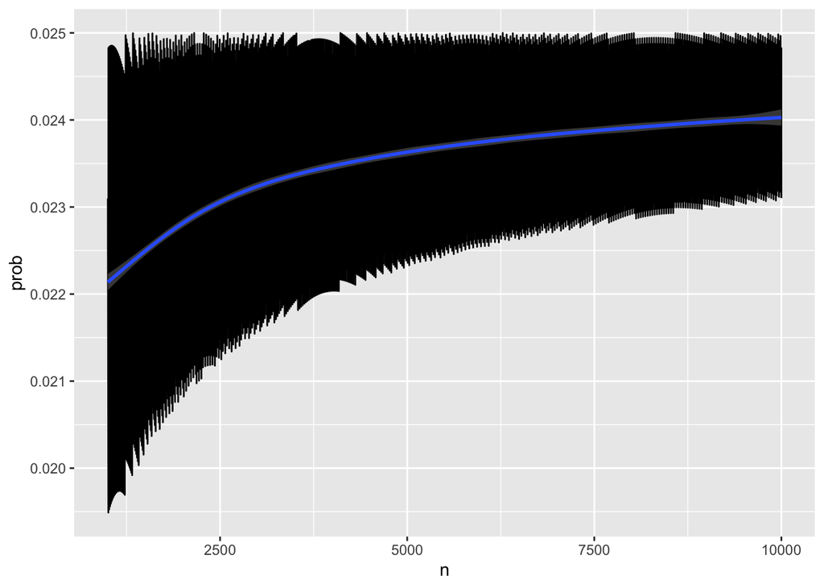

```r
prob4 %>%
  ggplot(aes(x=n, y=prob)) +
  geom_line() +
  geom_smooth()
```

### E

What is the average of the values of `prob` for $n > 9000$?

```r
prob4 %>%
  filter(n > 9000) %>%
  summarize(mean(prob))
```

```
## # A tibble: 1 × 1
##   `mean(prob)`
##          <dbl>
## 1       0.0240
```

### Problem 5

### A

What is the 0.975 quantile of the standard normal distribution?

```r
qnorm(0.975)
```

```
## [1] 1.959964
```

### B

What is the area to the right of this quantile?

```r
1 - pnorm(qnorm(0.975))
```

```
## [1] 0.025
```

### Problem 6

For the $\text{N}(500,100)$ distribution, find values $a$ and $b$ such that $a < b$, the area between $a$ and $b$ under the normal density is equal to 0.6, and $a$ and $b$ are equally distant from $\mu = 500$.

```r
a = qnorm(0.2, 500, 100)
b = qnorm(0.8, 500, 100)
pnorm(b, 500, 100) - pnorm(a, 500, 100)
```

```
## [1] 0.6
```

```r
500 - a
```

```
## [1] 84.16212
```

```r
b - 500
```

```
## [1] 84.16212
```

```r
paste("a:", a, "b:", b)
```

```
## [1] "a: 415.837876642709 b: 584.162123357291"
```

### Problem 7

Graph the $\text{N}(500,100)$ distribution and shade the area between $a$ and $b$ from the previous problem.

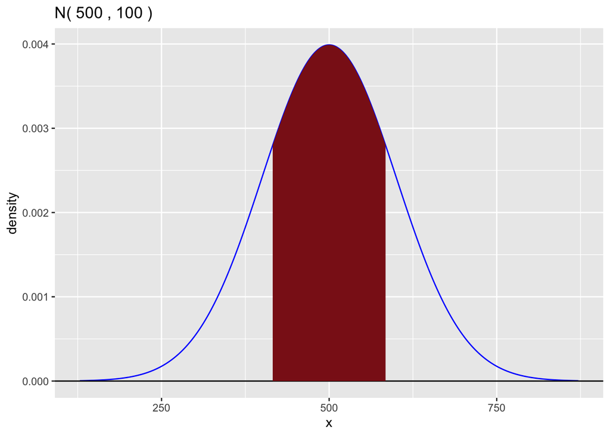

```r
gnorm(500, 100) +
  geom_norm_fill(mu=500, sigma=100, a=a, b=b)
```